Chapter 11

Practical Methodology

Successfully applying deep learning techniques requires more than just a good

knowledge of what algorithms exist and the principles that explain how they

work. A good machine learning practitioner also needs to know how to choose an

algorithm for a particular application and how to monitor and respond to feedback

obtained from experiments in order to improve a machine learning system. During

day-to-day development of machine learning systems, practitioners need to decide

whether to gather more data, increase or decrease model capacity, add or remove

regularizing features, improve the optimization of a model, improve approximate

inference in a model, or debug the software implementation of the model. All these

operations are at the very least time consuming to try out, so it is important to

be able to determine the right course of action rather than blindly guessing.

Most of this book is about diﬀerent machine learning models, training algo-

rithms, and objective functions. This may give the impression that the most

important ingredient to being a machine learning expert is knowing a wide variety

of machine learning techniques and being good at diﬀerent kinds of math. In prac-

tice, one can usually do much better with a correct application of a commonplace

algorithm than by sloppily applying an obscure algorithm. Correct application of

an algorithm depends on mastering some fairly simple methodology. Many of the

recommendations in this chapter are adapted from Ng (2015).

We recommend the following practical design process:

•

Determine your goals—what error metric to use, and your target value for

this error metric. These goals and error metrics should be driven by the

problem that the application is intended to solve.

•

Establish a working end-to-end pipeline as soon as possible, including the

416

CHAPTER 11. PRACTICAL METHODOLOGY

estimation of the appropriate performance metrics.

•

Instrument the system well to determine bottlenecks in performance. Diag-

nose which components are performing worse than expected and whether

poor performance is due to overﬁtting, underﬁtting, or a defect in the data

or software.

•

Repeatedly make incremental changes such as gathering new data, adjusting

hyperparameters, or changing algorithms, based on speciﬁc ﬁndings from

your instrumentation.

As a running example, we will use the Street View address number transcription

system (Goodfellow et al., 2014d). The purpose of this application is to add

buildings to Google Maps. Street View cars photograph the buildings and record

the GPS coordinates associated with each photograph. A convolutional network

recognizes the address number in each photograph, allowing the Google Maps

database to add that address in the correct location. The story of how this

commercial application was developed gives an example of how to follow the design

methodology we advocate.

We now describe each of the steps in this process.

11.1 Performance Metrics

Determining your goals, in terms of which error metric to use, is a necessary ﬁrst

step because your error metric will guide all your future actions. You should also

have an idea of what level of performance you desire.

Keep in mind that for most applications, it is impossible to achieve absolute

zero error. The Bayes error deﬁnes the minimum error rate that you can hope to

achieve, even if you have inﬁnite training data and can recover the true probability

distribution. This is because your input features may not contain complete

information about the output variable, or because the system might be intrinsically

stochastic. You will also be limited by having a ﬁnite amount of training data.

The amount of training data can be limited for a variety of reasons. When your

goal is to build the best possible real-world product or service, you can typically

collect more data but must determine the value of reducing error further and weigh

this against the cost of collecting more data. Data collection can require time,

money, or human suﬀering (for example, if your data collection process involves

performing invasive medical tests). When your goal is to answer a scientiﬁc question

about which algorithm performs better on a ﬁxed benchmark, the benchmark

417

CHAPTER 11. PRACTICAL METHODOLOGY

speciﬁcation usually determines the training set, and you are not allowed to collect

more data.

How can one determine a reasonable level of performance to expect? Typically,

in the academic setting, we have some estimate of the error rate that is attainable

based on previously published benchmark results. In the real-word setting, we

have some idea of the error rate that is necessary for an application to be safe,

cost-eﬀective, or appealing to consumers. Once you have determined your realistic

desired error rate, your design decisions will be guided by reaching this error rate.

Another important consideration besides the target value of the performance

metric is the choice of which metric to use. Several diﬀerent performance metrics

may be used to measure the eﬀectiveness of a complete application that includes

machine learning components. These performance metrics are usually diﬀerent

from the cost function used to train the model. As described in section 5.1.2, it is

common to measure the accuracy, or equivalently, the error rate, of a system.

However, many applications require more advanced metrics.

Sometimes it is much more costly to make one kind of a mistake than another.

For example, an e-mail spam detection system can make two kinds of mistakes:

incorrectly classifying a legitimate message as spam, and incorrectly allowing a

spam message to appear in the inbox. It is much worse to block a legitimate

message than to allow a questionable message to pass through. Rather than

measuring the error rate of a spam classiﬁer, we may wish to measure some form

of total cost, where the cost of blocking legitimate messages is higher than the cost

of allowing spam messages.

Sometimes we wish to train a binary classiﬁer that is intended to detect some

rare event. For example, we might design a medical test for a rare disease. Suppose

that only one in every million people has this disease. We can easily achieve

99.9999 percent accuracy on the detection task, by simply hard coding the classiﬁer

to always report that the disease is absent. Clearly, accuracy is a poor way to

characterize the performance of such a system. One way to solve this problem is

to instead measure

precision

and

recall

. Precision is the fraction of detections

reported by the model that were correct, while recall is the fraction of true events

that were detected. A detector that says no one has the disease would achieve

perfect precision, but zero recall. A detector that says everyone has the disease

would achieve perfect recall, but precision equal to the percentage of people who

have the disease (0.0001 percent in our example of a disease that only one people in

a million have). When using precision and recall, it is common to plot a

PR curve

,

with precision on the

y

-axis and recall on the

x

-axis. The classiﬁer generates a score

that is higher if the event to be detected occurred. For example, a feedforward

418

[figure not shown]

CHAPTER 11. PRACTICAL METHODOLOGY

network designed to detect a disease outputs

ˆy

=

P

(

y

= 1

| x

), estimating the

probability that a person whose medical results are described by features

x

has

the disease. We choose to report a detection whenever this score exceeds some

threshold. By varying the threshold, we can trade precision for recall. In many

cases, we wish to summarize the performance of the classiﬁer with a single number

rather than a curve. To do so, we can convert precision

p

and recall

r

into an

F-score given by

F =

2pr

p + r

. (11.1)

Another option is to report the total area lying beneath the PR curve.

In some applications, it is possible for the machine learning system to refuse to

make a decision. This is useful when the machine learning algorithm can estimate

how conﬁdent it should be about a decision, especially if a wrong decision can

be harmful and if a human operator is able to occasionally take over. The Street

View transcription system provides an example of this situation. The task is to

transcribe the address number from a photograph to associate the location where

the photo was taken with the correct address in a map. Because the value of the

map degrades considerably if the map is inaccurate, it is important to add an

address only if the transcription is correct. If the machine learning system thinks

that it is less likely than a human being to obtain the correct transcription, then the

best course of action is to allow a human to transcribe the photo instead. Of course,

the machine learning system is only useful if it is able to dramatically reduce the

amount of photos that the human operators must process. A natural performance

metric to use in this situation is

coverage

. Coverage is the fraction of examples

for which the machine learning system is able to produce a response. It is possible

to trade coverage for accuracy. One can always obtain 100 percent accuracy by

refusing to process any example, but this reduces the coverage to 0 percent. For the

Street View task, the goal for the project was to reach human-level transcription

accuracy while maintaining 95 percent coverage. Human-level performance on this

task is 98 percent accuracy.

Many other metrics are possible. We can, for example, measure click-through

rates, collect user satisfaction surveys, and so on. Many specialized application

areas have application-speciﬁc criteria as well.

What is important is to determine which performance metric to improve ahead

of time, then concentrate on improving this metric. Without clearly deﬁned goals,

it can be diﬃcult to tell whether changes to a machine learning system make

progress or not.

419

CHAPTER 11. PRACTICAL METHODOLOGY

11.2 Default Baseline Models

After choosing performance metrics and goals, the next step in any practical

application is to establish a reasonable end-to-end system as soon as possible. In

this section, we provide recommendations for which algorithms to use as the ﬁrst

baseline approach in various situations. Keep in mind that deep learning research

progresses quickly, so better default algorithms are likely to become available soon

after this writing.

Depending on the complexity of your problem, you may even want to begin

without using deep learning. If your problem has a chance of being solved by

just choosing a few linear weights correctly, you may want to begin with a simple

statistical model like logistic regression.

If you know that your problem falls into an “AI-complete” category like object

recognition, speech recognition, machine translation, and so on, then you are likely

to do well by beginning with an appropriate deep learning model.

First, choose the general category of model based on the structure of your

data. If you want to perform supervised learning with ﬁxed-size vectors as input,

use a feedforward network with fully connected layers. If the input has known

topological structure (for example, if the input is an image), use a convolutional

network. In these cases, you should begin by using some kind of piecewise linear

unit (ReLUs or their generalizations, such as Leaky ReLUs, PreLus, or maxout). If

your input or output is a sequence, use a gated recurrent net (LSTM or GRU).

A reasonable choice of optimization algorithm is SGD with momentum with

a decaying learning rate (popular decay schemes that perform better or worse

on diﬀerent problems include decaying linearly until reaching a ﬁxed minimum

learning rate, decaying exponentially, or decreasing the learning rate by a factor of

2–10 each time validation error plateaus). Another reasonable alternative is Adam.

Batch normalization can have a dramatic eﬀect on optimization performance,

especially for convolutional networks and networks with sigmoidal nonlinearities.

While it is reasonable to omit batch normalization from the very ﬁrst baseline, it

should be introduced quickly if optimization appears to be problematic.

Unless your training set contains tens of millions of examples or more, you

should include some mild forms of regularization from the start. Early stopping

should be used almost universally. Dropout is an excellent regularizer that is easy

to implement and compatible with many models and training algorithms. Batch

normalization also sometimes reduces generalization error and allows dropout to

be omitted, because of the noise in the estimate of the statistics used to normalize

each variable.

420

CHAPTER 11. PRACTICAL METHODOLOGY

If your task is similar to another task that has been studied extensively, you

will probably do well by ﬁrst copying the model and algorithm that is already

known to perform best on the previously studied task. You may even want to copy

a trained model from that task. For example, it is common to use the features

from a convolutional network trained on ImageNet to solve other computer vision

tasks (Girshick et al., 2015).

A common question is whether to begin by using unsupervised learning, de-

scribed further in part III. This is somewhat domain speciﬁc. Some domains, such

as natural language processing, are known to beneﬁt tremendously from unsuper-

vised learning techniques, such as learning unsupervised word embeddings. In

other domains, such as computer vision, current unsupervised learning techniques

do not bring a beneﬁt, except in the semi-supervised setting, when the number of

labeled examples is very small (Kingma et al., 2014; Rasmus et al., 2015). If your

application is in a context where unsupervised learning is known to be important,

then include it in your ﬁrst end-to-end baseline. Otherwise, only use unsupervised

learning in your ﬁrst attempt if the task you want to solve is unsupervised. You

can always try adding unsupervised learning later if you observe that your initial

baseline overﬁts.

11.3 Determining Whether to Gather More Data

After the ﬁrst end-to-end system is established, it is time to measure the perfor-

mance of the algorithm and determine how to improve it. Many machine learning

novices are tempted to make improvements by trying out many diﬀerent algorithms.

Yet, it is often much better to gather more data than to improve the learning

algorithm.

How does one decide whether to gather more data? First, determine whether

the performance on the training set is acceptable. If performance on the training

set is poor, the learning algorithm is not using the training data that is already

available, so there is no reason to gather more data. Instead, try increasing the

size of the model by adding more layers or adding more hidden units to each layer.

Also, try improving the learning algorithm, for example by tuning the learning

rate hyperparameter. If large models and carefully tuned optimization algorithms

do not work well, then the problem might be the quality of the training data. The

data may be too noisy or may not include the right inputs needed to predict the

desired outputs. This suggests starting over, collecting cleaner data, or collecting

a richer set of features.

If the performance on the training set is acceptable, then measure the per-

421

CHAPTER 11. PRACTICAL METHODOLOGY

formance on a test set. If the performance on the test set is also acceptable,

then there is nothing left to be done. If test set performance is much worse than

training set performance, then gathering more data is one of the most eﬀective

solutions. The key considerations are the cost and feasibility of gathering more

data, the cost and feasibility of reducing the test error by other means, and the

amount of data that is expected to be necessary to improve test set performance

signiﬁcantly. At large internet companies with millions or billions of users, it is

feasible to gather large datasets, and the expense of doing so can be considerably

less than that of the alternatives, so the answer is almost always to gather more

training data. For example, the development of large labeled datasets was one of

the most important factors in solving object recognition. In other contexts, such as

medical applications, it may be costly or infeasible to gather more data. A simple

alternative to gathering more data is to reduce the size of the model or improve

regularization, by adjusting hyperparameters such as weight decay coeﬃcients,

or by adding regularization strategies such as dropout. If you ﬁnd that the gap

between train and test performance is still unacceptable even after tuning the

regularization hyperparameters, then gathering more data is advisable.

When deciding whether to gather more data, it is also necessary to decide

how much to gather. It is helpful to plot curves showing the relationship between

training set size and generalization error, as in ﬁgure 5.4. By extrapolating such

curves, one can predict how much additional training data would be needed to

achieve a certain level of performance. Usually, adding a small fraction of the total

number of examples will not have a noticeable eﬀect on generalization error. It is

therefore recommended to experiment with training set sizes on a logarithmic scale,

for example, doubling the number of examples between consecutive experiments.

If gathering much more data is not feasible, the only other way to improve

generalization error is to improve the learning algorithm itself. This becomes the

domain of research and not the domain of advice for applied practitioners.

11.4 Selecting Hyperparameters

Most deep learning algorithms come with several hyperparameters that control

many aspects of the algorithm’s behavior. Some of these hyperparameters aﬀect the

time and memory cost of running the algorithm. Some of these hyperparameters

aﬀect the quality of the model recovered by the training process and its ability to

infer correct results when deployed on new inputs.

There are two basic approaches to choosing these hyperparameters: choosing

them manually and choosing them automatically. Choosing the hyperparameters

422

CHAPTER 11. PRACTICAL METHODOLOGY

manually requires understanding what the hyperparameters do and how machine

learning models achieve good generalization. Automatic hyperparameter selection

algorithms greatly reduce the need to understand these ideas, but they are often

much more computationally costly.

11.4.1 Manual Hyperparameter Tuning

To set hyperparameters manually, one must understand the relationship between

hyperparameters, training error, generalization error and computational resources

(memory and runtime). This means establishing a solid foundation on the funda-

mental ideas concerning the eﬀective capacity of a learning algorithm, as described

in chapter 5.

The goal of manual hyperparameter search is usually to ﬁnd the lowest general-

ization error subject to some runtime and memory budget. We do not discuss how

to determine the runtime and memory impact of various hyperparameters here

because this is highly platform dependent.

The primary goal of manual hyperparameter search is to adjust the eﬀective

capacity of the model to match the complexity of the task. Eﬀective capacity

is constrained by three factors: the representational capacity of the model, the

ability of the learning algorithm to successfully minimize the cost function used to

train the model, and the degree to which the cost function and training procedure

regularize the model. A model with more layers and more hidden units per layer has

higher representational capacity—it is capable of representing more complicated

functions. It cannot necessarily learn all these functions though, if the training

algorithm cannot discover that certain functions do a good job of minimizing the

training cost, or if regularization terms such as weight decay forbid some of these

functions.

The generalization error typically follows a U-shaped curve when plotted as

a function of one of the hyperparameters, as in ﬁgure 5.3. At one extreme, the

hyperparameter value corresponds to low capacity, and generalization error is high

because training error is high. This is the underﬁtting regime. At the other extreme,

the hyperparameter value corresponds to high capacity, and the generalization

error is high because the gap between training and test error is high. Somewhere

in the middle lies the optimal model capacity, which achieves the lowest possible

generalization error, by adding a medium generalization gap to a medium amount

of training error.

For some hyperparameters, overﬁtting occurs when the value of the hyper-

parameter is large. The number of hidden units in a layer is one such example,

423

CHAPTER 11. PRACTICAL METHODOLOGY

because increasing the number of hidden units increases the capacity of the model.

For some hyperparameters, overﬁtting occurs when the value of the hyperparame-

ter is small. For example, the smallest allowable weight decay coeﬃcient of zero

corresponds to the greatest eﬀective capacity of the learning algorithm.

Not every hyperparameter will be able to explore the entire U-shaped curve.

Many hyperparameters are discrete, such as the number of units in a layer or the

number of linear pieces in a maxout unit, so it is only possible to visit a few points

along the curve. Some hyperparameters are binary. Usually these hyperparameters

are switches that specify whether or not to use some optional component of

the learning algorithm, such as a preprocessing step that normalizes the input

features by subtracting their mean and dividing by their standard deviation. These

hyperparameters can explore only two points on the curve. Other hyperparameters

have some minimum or maximum value that prevents them from exploring some

part of the curve. For example, the minimum weight decay coeﬃcient is zero. This

means that if the model is underﬁtting when weight decay is zero, we cannot enter

the overﬁtting region by modifying the weight decay coeﬃcient. In other words,

some hyperparameters can only subtract capacity.

The learning rate is perhaps the most important hyperparameter. If you

have time to tune only one hyperparameter, tune the learning rate. It con-

trols the eﬀective capacity of the model in a more complicated way than other

hyperparameters—the eﬀective capacity of the model is highest when the learning

rate is correct for the optimization problem, not when the learning rate is especially

large or especially small. The learning rate has a U-shaped curve for training error,

illustrated in ﬁgure 11.1. When the learning rate is too large, gradient descent

can inadvertently increase rather than decrease the training error. In the idealized

quadratic case, this occurs if the learning rate is at least twice as large as its

optimal value (LeCun et al., 1998a). When the learning rate is too small, training

is not only slower but may become permanently stuck with a high training error.

This eﬀect is poorly understood (it would not happen for a convex loss function).

Tuning the parameters other than the learning rate requires monitoring both

training and test error to diagnose whether your model is overﬁtting or underﬁtting,

then adjusting its capacity appropriately.

If your error on the training set is higher than your target error rate, you have

no choice but to increase capacity. If you are not using regularization and you are

conﬁdent that your optimization algorithm is performing correctly, then you must

add more layers to your network or add more hidden units. Unfortunately, this

increases the computational costs associated with the model.

If your error on the test set is higher than your target error rate, you can now

424

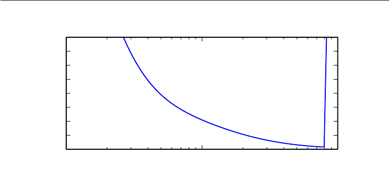

CHAPTER 11. PRACTICAL METHODOLOGY

10

−2

10

−1

10

0

Learning rate (logarithmic scale)

0

1

2

3

4

5

6

7

8

Training error

Figure 11.1: Typical relationship between the learning rate and the training error. Notice

the sharp rise in error when the learning is above an optimal value. This is for a ﬁxed

training time, as a smaller learning rate may sometimes only slow down training by a factor

proportional to the learning rate reduction. Generalization error can follow this curve

or be complicated by regularization eﬀects arising out of having too large or too small

learning rates, since poor optimization can, to some degree, reduce or prevent overﬁtting,

and even points with equivalent training error can have diﬀerent generalization error.

take two kinds of actions. The test error is the sum of the training error and the

gap between training and test error. The optimal test error is found by trading

oﬀ these quantities. Neural networks typically perform best when the training

error is very low (and thus, when capacity is high) and the test error is primarily

driven by the gap between training and test error. Your goal is to reduce this gap

without increasing training error faster than the gap decreases. To reduce the gap,

change regularization hyperparameters to reduce eﬀective model capacity, such as

by adding dropout or weight decay. Usually the best performance comes from a

large model that is regularized well, for example, by using dropout.

Most hyperparameters can be set by reasoning about whether they increase or

decrease model capacity. Some examples are included in table 11.1.

While manually tuning hyperparameters, do not lose sight of your end goal:

good performance on the test set. Adding regularization is only one way to achieve

this goal. As long as you have low training error, you can always reduce general-

ization error by collecting more training data. The brute force way to practically

guarantee success is to continually increase model capacity and training set size

until the task is solved. This approach does of course increase the computational

cost of training and inference, so it is only feasible given appropriate resources. In

principle, this approach could fail due to optimization diﬃculties, but for many

425

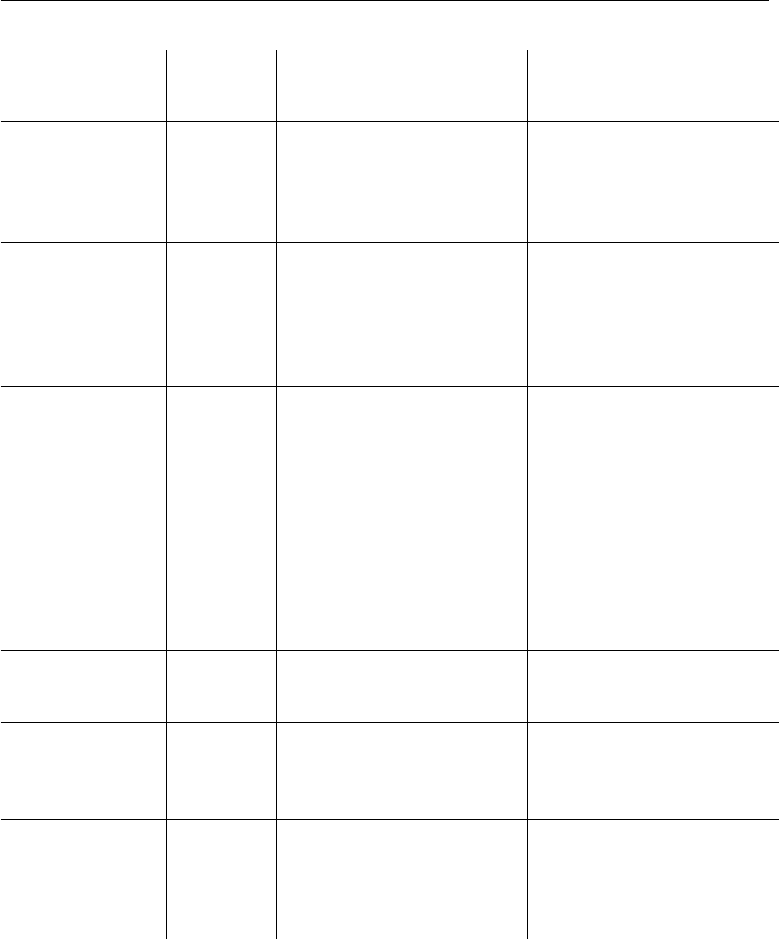

CHAPTER 11. PRACTICAL METHODOLOGY

Hyperparameter

Increases

capacity

when. . .

Reason Caveats

Number of hid-

den units

increased

Increasing the number of

hidden units increases the

representational capacity

of the model.

Increasing the number

of hidden units increases

both the time and memory

cost of essentially every op-

eration on the model.

Learning rate

tuned op-

timally

An improper learning rate,

whether too high or too

low, results in a model

with low eﬀective capac-

ity due to optimization fail-

ure.

Convolution ker-

nel width

increased

Increasing the kernel width

increases the number of pa-

rameters in the model.

A wider kernel results

in a narrower output di-

mension, reducing model

capacity unless you use

implicit zero padding to

reduce this eﬀect. Wider

kernels require more mem-

ory for parameter storage

and increase runtime, but

a narrower output reduces

memory cost.

Implicit zero

padding

increased

Adding implicit zeros be-

fore convolution keeps the

representation size large.

Increases time and mem-

ory cost of most opera-

tions.

Weight decay co-

eﬃcient

decreased

Decreasing the weight de-

cay coeﬃcient frees the

model parameters to be-

come larger.

Dropout rate decreased

Dropping units less often

gives the units more oppor-

tunities to “conspire” with

each other to ﬁt the train-

ing set.

Table 11.1: The eﬀect of various hyperparameters on model capacity.

problems optimization does not seem to be a signiﬁcant barrier, provided that the

model is chosen appropriately.

426

CHAPTER 11. PRACTICAL METHODOLOGY

11.4.2 Automatic Hyperparameter Optimization Algorithms

The ideal learning algorithm just takes a dataset and outputs a function, without

requiring hand tuning of hyperparameters. The popularity of several learning

algorithms such as logistic regression and SVMs stems in part from their ability to

perform well with only one or two tuned hyperparameters. Neural networks can

sometimes perform well with only a small number of tuned hyperparameters, but

often beneﬁt signiﬁcantly from tuning of forty or more. Manual hyperparameter

tuning can work very well when the user has a good starting point, such as

one determined by others having worked on the same type of application and

architecture, or when the user has months or years of experience in exploring

hyperparameter values for neural networks applied to similar tasks. For many

applications, however, these starting points are not available. In these cases,

automated algorithms can ﬁnd useful values of the hyperparameters.

If we think about the way in which the user of a learning algorithm searches for

good values of the hyperparameters, we realize that an optimization is taking place:

we are trying to ﬁnd a value of the hyperparameters that optimizes an objective

function, such as validation error, sometimes under constraints (such as a budget

for training time, memory or recognition time). It is therefore possible, in principle,

to develop

hyperparameter optimization

algorithms that wrap a learning

algorithm and choose its hyperparameters, thus hiding the hyperparameters of the

learning algorithm from the user. Unfortunately, hyperparameter optimization

algorithms often have their own hyperparameters, such as the range of values that

should be explored for each of the learning algorithm’s hyperparameters. These

secondary hyperparameters are usually easier to choose, however, in the sense that

acceptable performance may be achieved on a wide range of tasks using the same

secondary hyperparameters for all tasks.

11.4.3 Grid Search

When there are three or fewer hyperparameters, the common practice is to perform

grid search

. For each hyperparameter, the user selects a small ﬁnite set of

values to explore. The grid search algorithm then trains a model for every joint

speciﬁcation of hyperparameter values in the Cartesian product of the set of values

for each individual hyperparameter. The experiment that yields the best validation

set error is then chosen as having found the best hyperparameters. See the left of

ﬁgure 11.2 for an illustration of a grid of hyperparameter values.

How should the lists of values to search over be chosen? In the case of numerical

(ordered) hyperparameters, the smallest and largest element of each list is chosen

427

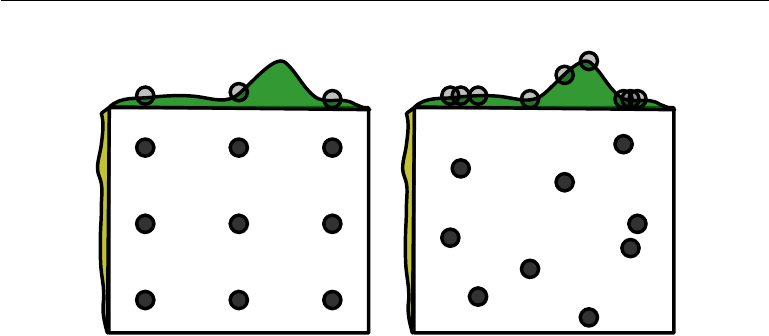

CHAPTER 11. PRACTICAL METHODOLOGY

Grid Layout Random Layout

Unimportant parameter

Important parameter

Unimportant parameter

Important parameter

Grid Layout Random Layout

Unimportant parameter

Important parameter

Unimportant parameter

Important parameter

Grid Random

Figure 11.2: Comparison of grid search and random search. For illustration purposes, we

display two hyperparameters, but we are typically interested in having many more. (Left)

To perform grid search, we provide a set of values for each hyperparameter. The search

algorithm runs training for every joint hyperparameter setting in the cross product of these

sets. (Right) To perform random search, we provide a probability distribution over joint

hyperparameter conﬁgurations. Usually most of these hyperparameters are independent

from each other. Common choices for the distribution over a single hyperparameter include

uniform and log-uniform (to sample from a log-uniform distribution, take the

exp

of a

sample from a uniform distribution). The search algorithm then randomly samples joint

hyperparameter conﬁgurations and runs training with each of them. Both grid search

and random search evaluate the validation set error and return the best conﬁguration.

The ﬁgure illustrates the typical case where only some hyperparameters have a signiﬁcant

inﬂuence on the result. In this illustration, only the hyperparameter on the horizontal axis

has a signiﬁcant eﬀect. Grid search wastes an amount of computation that is exponential

in the number of noninﬂuential hyperparameters, while random search tests a unique

value of every inﬂuential hyperparameter on nearly every trial. Figure reproduced with

permission from Bergstra and Bengio (2012).

conservatively, based on prior experience with similar experiments, to make sure

that the optimal value is likely to be in the selected range. Typically, a grid search

involves picking values approximately on a logarithmic scale, e.g., a learning rate

taken within the set

{

0

.

1

,

0

.

01

,

10

−3

,

10

−4

,

10

−5

}

, or a number of hidden units

taken with the set {50, 100, 200, 500, 1000, 2000}.

Grid search usually performs best when it is performed repeatedly. For example,

suppose that we ran a grid search over a hyperparameter

α

using values of

{−

1

,

0

,

1

}

.

If the best value found is 1, then we underestimated the range in which the best

α

lies and should shift the grid and run another search with

α

in, for example,

{

1

,

2

,

3

}

. If we ﬁnd that the best value of

α

is 0, then we may wish to reﬁne our

428

CHAPTER 11. PRACTICAL METHODOLOGY

estimate by zooming in and running a grid search over {−0.1, 0, 0.1}.

The obvious problem with grid search is that its computational cost grows

exponentially with the number of hyperparameters. If there are

m

hyperparameters,

each taking at most

n

values, then the number of training and evaluation trials

required grows as

O

(

n

m

). The trials may be run in parallel and exploit loose

parallelism (with almost no need for communication between diﬀerent machines

carrying out the search). Unfortunately, because of the exponential cost of grid

search, even parallelization may not provide a satisfactory size of search.

11.4.4 Random Search

Fortunately, there is an alternative to grid search that is as simple to program, more

convenient to use, and converges much faster to good values of the hyperparameters:

random search (Bergstra and Bengio, 2012).

A random search proceeds as follows. First we deﬁne a marginal distribution

for each hyperparameter, for example, a Bernoulli or multinoulli for binary or

discrete hyperparameters, or a uniform distribution on a log-scale for positive

real-valued hyperparameters. For example,

log_learning_rate ∼ u(−1, −5), (11.2)

learning_rate = 10

log_learning_rate

, (11.3)

where

u

(

a, b

) indicates a sample of the uniform distribution in the interval (

a, b

).

Similarly the

log_number_of_hidden_units

may be sampled from

u

(

log

(50)

,

log(2000)).

Unlike in a grid search, we should not discretize or bin the values of the hy-

perparameters, so that we can explore a larger set of values and avoid additional

computational cost. In fact, as illustrated in ﬁgure 11.2, a random search can be

exponentially more eﬃcient than a grid search, when there are several hyperpa-

rameters that do not strongly aﬀect the performance measure. This is studied at

length in Bergstra and Bengio (2012), who found that random search reduces the

validation set error much faster than grid search, in terms of the number of trials

run by each method.

As with grid search, we may often want to run repeated versions of random

search, to reﬁne the search based on the results of the ﬁrst run.

The main reason that random search ﬁnds good solutions faster than grid

search is that it has no wasted experimental runs, unlike in the case of grid search,

when two values of a hyperparameter (given values of the other hyperparameters)

429

CHAPTER 11. PRACTICAL METHODOLOGY

would give the same result. In the case of grid search, the other hyperparameters

would have the same values for these two runs, whereas with random search, they

would usually have diﬀerent values. Hence if the change between these two values

does not marginally make much diﬀerence in terms of validation set error, grid

search will unnecessarily repeat two equivalent experiments while random search

will still give two independent explorations of the other hyperparameters.

11.4.5 Model-Based Hyperparameter Optimization

The search for good hyperparameters can be cast as an optimization problem.

The decision variables are the hyperparameters. The cost to be optimized is the

validation set error that results from training using these hyperparameters. In

simpliﬁed settings where it is feasible to compute the gradient of some diﬀerentiable

error measure on the validation set with respect to the hyperparameters, we can

simply follow this gradient (Bengio et al., 1999; Bengio, 2000; Maclaurin et al.,

2015). Unfortunately, in most practical settings, this gradient is unavailable, either

because of its high computation and memory cost, or because of hyperparameters

that have intrinsically nondiﬀerentiable interactions with the validation set error,

as in the case of discrete-valued hyperparameters.

To compensate for this lack of a gradient, we can build a model of the validation

set error, then propose new hyperparameter guesses by performing optimization

within this model. Most model-based algorithms for hyperparameter search use a

Bayesian regression model to estimate both the expected value of the validation set

error for each hyperparameter and the uncertainty around this expectation. Opti-

mization thus involves a trade-oﬀ between exploration (proposing hyperparameters

for that there is high uncertainty, which may lead to a large improvement but may

also perform poorly) and exploitation (proposing hyperparameters that the model

is conﬁdent will perform as well as any hyperparameters it has seen so far—usually

hyperparameters that are very similar to ones it has seen before). Contemporary

approaches to hyperparameter optimization include Spearmint (Snoek et al., 2012),

TPE (Bergstra et al., 2011) and SMAC (Hutter et al., 2011).

Currently, we cannot unambiguously recommend Bayesian hyperparameter

optimization as an established tool for achieving better deep learning results or

for obtaining those results with less eﬀort. Bayesian hyperparameter optimization

sometimes performs comparably to human experts, sometimes better, but fails

catastrophically on other problems. It may be worth trying to see if it works on a

particular problem but is not yet suﬃciently mature or reliable. That being said,

hyperparameter optimization is an important ﬁeld of research that, while often

driven primarily by the needs of deep learning, holds the potential to beneﬁt not

430

CHAPTER 11. PRACTICAL METHODOLOGY

only the entire ﬁeld of machine learning but also the discipline of engineering in

general.

One drawback common to most hyperparameter optimization algorithms with

more sophistication than random search is that they require for a training ex-

periment to run to completion before they are able to extract any information

from the experiment. This is much less eﬃcient, in the sense of how much infor-

mation can be gleaned early in an experiment, than manual search by a human

practitioner, since one can usually tell early on if some set of hyperparameters is

completely pathological. Swersky et al. (2014) have introduced an early version

of an algorithm that maintains a set of multiple experiments. At various time

points, the hyperparameter optimization algorithm can choose to begin a new

experiment, to “freeze” a running experiment that is not promising, or to “thaw”

and resume an experiment that was earlier frozen but now appears promising given

more information.

11.5 Debugging Strategies

When a machine learning system performs poorly, it is usually diﬃcult to tell

whether the poor performance is intrinsic to the algorithm itself or whether there

is a bug in the implementation of the algorithm. Machine learning systems are

diﬃcult to debug for various reasons.

In most cases, we do not know a priori what the intended behavior of the

algorithm is. In fact, the entire point of using machine learning is that it will

discover useful behavior that we were not able to specify ourselves. If we train a

neural network on a new classiﬁcation task and it achieves 5 percent test error,

we have no straightforward way of knowing if this is the expected behavior or

suboptimal behavior.

A further diﬃculty is that most machine learning models have multiple parts

that are each adaptive. If one part is broken, the other parts can adapt and still

achieve roughly acceptable performance. For example, suppose that we are training

a neural net with several layers parametrized by weights

W

and biases

b

. Suppose

further that we have manually implemented the gradient descent rule for each

parameter separately, and we made an error in the update for the biases:

b ← b − α, (11.4)

where

α

is the learning rate. This erroneous update does not use the gradient at

all. It causes the biases to constantly become negative throughout learning, which

431

CHAPTER 11. PRACTICAL METHODOLOGY

is clearly not a correct implementation of any reasonable learning algorithm. The

bug may not be apparent just from examining the output of the model though.

Depending on the distribution of the input, the weights may be able to adapt to

compensate for the negative biases.

Most debugging strategies for neural nets are designed to get around one or

both of these two diﬃculties. Either we design a case that is so simple that the

correct behavior actually can be predicted, or we design a test that exercises one

part of the neural net implementation in isolation.

Some important debugging tests include the following.

Visualize the model in action: When training a model to detect objects in

images, view some images with the detections proposed by the model displayed

superimposed on the image. When training a generative model of speech, listen to

some of the speech samples it produces. This may seem obvious, but it is easy to

fall into the practice of looking only at quantitative performance measurements

like accuracy or log-likelihood. Directly observing the machine learning model

performing its task will help to determine whether the quantitative performance

numbers it achieves seem reasonable. Evaluation bugs can be some of the most

devastating bugs because they can mislead you into believing your system is

performing well when it is not.

Visualize the worst mistakes: Most models are able to output some sort of

conﬁdence measure for the task they perform. For example, classiﬁers based on a

softmax output layer assign a probability to each class. The probability assigned

to the most likely class thus gives an estimate of the conﬁdence the model has in

its classiﬁcation decision. Typically, maximum likelihood training results in these

values being overestimates rather than accurate probabilities of correct prediction,

but they are somewhat useful in the sense that examples that are actually less likely

to be correctly labeled receive smaller probabilities under the model. By viewing

the training set examples that are the hardest to model correctly, one can often

discover problems with the way the data have been preprocessed or labeled. For

example, the Street View transcription system originally had a problem where the

address number detection system would crop the image too tightly and omit some

digits. The transcription network then assigned very low probability to the correct

answer on these images. Sorting the images to identify the most conﬁdent mistakes

showed that there was a systematic problem with the cropping. Modifying the

detection system to crop much wider images resulted in much better performance

of the overall system, even though the transcription network needed to be able to

process greater variation in the position and scale of the address numbers.

Reason about software using training and test error: It is often diﬃcult to

432

[figure not shown]

CHAPTER 11. PRACTICAL METHODOLOGY

determine whether the underlying software is correctly implemented. Some clues

can be obtained from the training and test errors. If training error is low but test

error is high, then it is likely that that the training procedure works correctly,

and the model is overﬁtting for fundamental algorithmic reasons. An alternative

possibility is that the test error is measured incorrectly because of a problem with

saving the model after training then reloading it for test set evaluation, or because

the test data was prepared diﬀerently from the training data. If both training and

test errors are high, then it is diﬃcult to determine whether there is a software

defect or whether the model is underﬁtting due to fundamental algorithmic reasons.

This scenario requires further tests, described next.

Fit a tiny dataset: If you have high error on the training set, determine whether

it is due to genuine underﬁtting or due to a software defect. Usually even small

models can be guaranteed to be able ﬁt a suﬃciently small dataset. For example,

a classiﬁcation dataset with only one example can be ﬁt just by setting the biases

of the output layer correctly. Usually if you cannot train a classiﬁer to correctly

label a single example, an autoencoder to successfully reproduce a single example

with high ﬁdelity, or a generative model to consistently emit samples resembling a

single example, there is a software defect preventing successful optimization on the

training set. This test can be extended to a small dataset with few examples.

Compare back-propagated derivatives to numerical derivatives: If you are using

a software framework that requires you to implement your own gradient com-

putations, or if you are adding a new operation to a diﬀerentiation library and

must deﬁne its

bprop

method, then a common source of error is implementing this

gradient expression incorrectly. One way to verify that these derivatives are correct

is to compare the derivatives computed by your implementation of automatic

diﬀerentiation to the derivatives computed by ﬁnite diﬀerences. Because

f

(x) = lim

→0

we can approximate the derivative by using a small, ﬁnite :

f

(x) ≈

We can improve the accuracy of the approximation by using the

centered diﬀer-

ence:

f

(x) ≈

f(x +

1

2

) − f(x −

1

2

)

. (11.7)

The perturbation size

must be large enough to ensure that the perturbation is

not rounded down too much by ﬁnite-precision numerical computations.

433

[figure not shown]

CHAPTER 11. PRACTICAL METHODOLOGY

Usually, we will want to test the gradient or Jacobian of a vector-valued function

g

:

R

m

→ R

n

. Unfortunately, ﬁnite diﬀerencing only allows us to take a single

derivative at a time. We can either run ﬁnite diﬀerencing

mn

times to evaluate all

the partial derivatives of

g

, or apply the test to a new function that uses random

projections at both the input and the output of

g

. For example, we can apply

our test of the implementation of the derivatives to

f

(

x

), where

f

(

x

) =

u

T

g

(

vx

),

and

u

and

v

are randomly chosen vectors. Computing

f

(

x

) correctly requires

being able to back-propagate through

g

correctly yet is eﬃcient to do with ﬁnite

diﬀerences because

f

has only a single input and a single output. It is usually

a good idea to repeat this test for more than one value of

u

and

v

to reduce

the chance of the test overlooking mistakes that are orthogonal to the random

projection.

If one has access to numerical computation on complex numbers, then there is

a very eﬃcient way to numerically estimate the gradient by using complex numbers

as input to the function (Squire and Trapp, 1998). The method is based on the

observation that

f(x + i) = f(x) + if

(x) + O(

2

), (11.8)

real(f(x + i)) = f(x) + O(

2

), imag(

f(x + i)

) = f

(x) + O(

2

), (11.9)

where

i

=

√

−1

. Unlike in the real-valued case above, there is no cancellation

eﬀect because we take the diﬀerence between the value of

f

at diﬀerent points.

This allows the use of tiny values of

, like

= 10

−150

, which make the

O

(

2

) error

insigniﬁcant for all practical purposes.

Monitor histograms of activations and gradient: It is often useful to visualize

statistics of neural network activations and gradients, collected over a large amount

of training iterations (maybe one epoch). The preactivation value of hidden units

can tell us if the units saturate, or how often they do. For example, for rectiﬁers,

how often are they oﬀ? Are there units that are always oﬀ? For tanh units,

the average of the absolute value of the preactivations tells us how saturated

the unit is. In a deep network where the propagated gradients quickly grow or

quickly vanish, optimization may be hampered. Finally, it is useful to compare the

magnitude of parameter gradients to the magnitude of the parameters themselves.

As suggested by Bottou (2015), we would like the magnitude of parameter updates

over a minibatch to represent something like 1 percent of the magnitude of the

parameter, not 50 percent or 0.001 percent (which would make the parameters

move too slowly). It may be that some groups of parameters are moving at a good

pace while others are stalled. When the data is sparse (like in natural language),

434

CHAPTER 11. PRACTICAL METHODOLOGY

some parameters may be very rarely updated, and this should be kept in mind

when monitoring their evolution.

Finally, many deep learning algorithms provide some sort of guarantee about

the results produced at each step. For example, in part III, we will see some approx-

imate inference algorithms that work by using algebraic solutions to optimization

problems. Typically these can be debugged by testing each of their guarantees.

Some guarantees that some optimization algorithms oﬀer include that the objective

function will never increase after one step of the algorithm, that the gradient with

respect to some subset of variables will be zero after each step of the algorithm,

and that the gradient with respect to all variables will be zero at convergence.

Usually due to rounding error, these conditions will not hold exactly in a digital

computer, so the debugging test should include some tolerance parameter.

11.6 Example: Multi-Digit Number Recognition

To provide an end-to-end description of how to apply our design methodology

in practice, we present a brief account of the Street View transcription system,

from the point of view of designing the deep learning components. Obviously,

many other components of the complete system, such as the Street View cars, the

database infrastructure, and so on, were of paramount importance.

From the point of view of the machine learning task, the process began with

data collection. The cars collected the raw data, and human operators provided

labels. The transcription task was preceded by a signiﬁcant amount of dataset

curation, including using other machine learning techniques to detect the house

numbers prior to transcribing them.

The transcription project began with a choice of performance metrics and

desired values for these metrics. An important general principle is to tailor the

choice of metric to the business goals for the project. Because maps are only useful

if they have high accuracy, it was important to set a high accuracy requirement for

this project. Speciﬁcally, the goal was to obtain human-level, 98 percent accuracy.

This level of accuracy may not always be feasible to obtain. To reach this level of

accuracy, the Street View transcription system sacriﬁced coverage. Coverage thus

became the main performance metric optimized during the project, with accuracy

held at 98 percent. As the convolutional network improved, it became possible to

reduce the conﬁdence threshold below which the network refused to transcribe the

input, eventually exceeding the goal of 95 percent coverage.

After choosing quantitative goals, the next step in our recommended methodol-

435

CHAPTER 11. PRACTICAL METHODOLOGY

ogy is to rapidly establish a sensible baseline system. For vision tasks, this means a

convolutional network with rectiﬁed linear units. The transcription project began

with such a model. At the time, it was not common for a convolutional network

to output a sequence of predictions. To begin with the simplest possible baseline,

the ﬁrst implementation of the output layer of the model consisted of

n

diﬀerent

softmax units to predict a sequence of

n

characters. These softmax units were

trained exactly the same as if the task were classiﬁcation, with each softmax unit

trained independently.

Our recommended methodology is to iteratively reﬁne the baseline and test

whether each change makes an improvement. The ﬁrst change to the Street View

transcription system was motivated by a theoretical understanding of the coverage

metric and the structure of the data. Speciﬁcally, the network refused to classify

an input

x

whenever the probability of the output sequence

p

(

y | x

)

< t

for

some threshold

t

. Initially, the deﬁnition of

p

(

y | x

) was ad-hoc, based on simply

multiplying all the softmax outputs together. This motivated the development of

a specialized output layer and cost function that actually computed a principled

log-likelihood. This approach allowed the example rejection mechanism to function

much more eﬀectively.

At this point, coverage was still below 90 percent, yet there were no obvious

theoretical problems with the approach. Our methodology therefore suggested

instrumenting the training and test set performance to determine whether the

problem was underﬁtting or overﬁtting. In this case, training and test set error

were nearly identical. Indeed, the main reason this project proceeded so smoothly

was the availability of a dataset with tens of millions of labeled examples. Because

training and test set error were so similar, this suggested that the problem was due

to either underﬁtting or a problem with the training data. One of the debugging

strategies we recommend is to visualize the model’s worst errors. In this case, that

meant visualizing the incorrect training set transcriptions that the model gave the

highest conﬁdence. These proved to mostly consist of examples where the input

image had been cropped too tightly, with some of the digits of the address being

removed by the cropping operation. For example, a photo of an address “1849”

might be cropped too tightly, with only the “849” remaining visible. This problem

could have been resolved by spending weeks improving the accuracy of the address

number detection system responsible for determining the cropping regions. Instead,

the team made a much more practical decision, to simply expand the width of the

crop region to be systematically wider than the address number detection system

predicted. This single change added ten percentage points to the transcription

system’s coverage.

436

CHAPTER 11. PRACTICAL METHODOLOGY

Finally, the last few percentage points of performance came from adjusting

hyperparameters. This mostly consisted of making the model larger while main-

taining some restrictions on its computational cost. Because train and test error

remained roughly equal, it was always clear that any performance deﬁcits were

due to underﬁtting, as well as to a few remaining problems with the dataset itself.

Overall, the transcription project was a great success and allowed hundreds of

millions of addresses to be transcribed both faster and at lower cost than would

have been possible via human eﬀort.

We hope that the design principles described in this chapter will lead to many

other similar successes.

437